# results_network_analysis

Stefan Haußner

25 Juli 2019

# Analyse der MEPs

## In- und Outdegree:

Welche MEPs folgen besonders vielen anderen im Netzwerk oder werden besonders gefolgt?

Der `Grad` eines Netzwerks ist ein einfaches Zentralitätsmaß, das zählt, wie viele Nachbarn ein Knoten hat. Wenn das Netzwerk gerichtet ist, haben wir zwei Versionen des Maßes: Der `in-degree` ist die Anzahl der eingehenden Verbindungen während der `out-degree` die Anzahl der ausgehenden Kanten ist. In einem ungerichteten Netzwerk ist der in- und der out-degree identisch.

Der Abgeordnete mit den meisten Followern (innerhalb der MEPs) ist Frans Timmermans (229 MEPs folgen ihm). Derjenige Abgeordnete, der den meisten anderen MEPs folgt ist Tomáš ZDECHOVSKÝ (EPP, Czech Rep.), der 578 von 621 twitter-aktiven MEPs folgt.

Top20 der MEPs sowohl der ausgehenden als auch der eingehenden Kontakte. Die Tabellen wären auch nach nach Fraktionen oder Nationen aufteilbar.

Most followers

| twitter_id | indegree | name | twitter_name | group | natparty | country |
| --- | --- | --- | --- | --- | --- | --- |
| 1391776140 | 229 | Frans TIMMERMANS | TimmermansEU | Group of the Progressive Alliance of Socialists and Democrats in the European Parliament | Partij van de Arbeid | Netherlands |
| 856010760 | 224 | Guy VERHOFSTADT | guyverhofstadt | Renew Europe Group | Open Vlaamse Liberalen en Democraten | Belgium |
| 20399735 | 183 | Manfred WEBER | ManfredWeber | Group of the European People’s Party (Christian Democrats) | Christlich-Soziale Union in Bayern e.V. | Germany |
| 16600393 | 138 | Ska KELLER | SkaKeller | Group of the Greens/European Free Alliance | Bündnis 90/Die Grünen | Germany |
| 529247064 | 126 | Antonio TAJANI | Antonio_Tajani | Group of the European People’s Party (Christian Democrats) | Forza Italia | Italy |
| 104782747 | 106 | Jerzy BUZEK | JerzyBuzek | Group of the European People’s Party (Christian Democrats) | Koalicja Europejska | Poland |
| 2803587655 | 103 | Andrus ANSIP | Ansip_EU | Renew Europe Group | Eesti Reformierakond | Estonia |
| 54988878 | 97 | David-Maria SASSOLI | DavidSassoli | Group of the Progressive Alliance of Socialists and Democrats in the European Parliament | Partito Democratico | Italy |
| 900231078 | 96 | Iratxe GARCÍA PÉREZ | IratxeGarper | Group of the Progressive Alliance of Socialists and Democrats in the European Parliament | Partido Socialista Obrero Español | Spain |
| 1586266080 | 95 | Corina CREȚU | CorinaCretuEU | Group of the Progressive Alliance of Socialists and Democrats in the European Parliament | PRO Romania | Romania |
| 4171877789 | 94 | Dacian CIOLOS | CiolosDacian | Renew Europe Group | Partidul Libertate, Unitate și Solidaritate | Romania |
| 2461432297 | 91 | Udo BULLMANN | UdoBullmann | Group of the Progressive Alliance of Socialists and Democrats in the European Parliament | Sozialdemokratische Partei Deutschlands | Germany |
| 560188351 | 91 | Terry REINTKE | TerryReintke | Group of the Greens/European Free Alliance | Bündnis 90/Die Grünen | Germany |
| 19763668 | 87 | Bas EICKHOUT | BasEickhout | Group of the Greens/European Free Alliance | GroenLinks | Netherlands |
| 19231330 | 87 | Sophia in ’t VELD | SophieintVeld | Renew Europe Group | Democraten 66 | Netherlands |
| 20610385 | 82 | Reinhard BÜTIKOFER | bueti | Group of the Greens/European Free Alliance | Bündnis 90/Die Grünen | Germany |
| 16705726 | 81 | Sven GIEGOLD | sven_giegold | Group of the Greens/European Free Alliance | Bündnis 90/Die Grünen | Germany |
| 165786404 | 81 | Philippe LAMBERTS | ph_lamberts | Group of the Greens/European Free Alliance | Ecologistes Confédérés pour l’Organisation de Luttes Originales | Belgium |
| 2615239693 | 75 | Tomáš ZDECHOVSKÝ | TomZdechovskyEP | Group of the European People’s Party (Christian Democrats) | Křesťanská a demokratická unie - Československá strana lidová | Czechia |
| 45360352 | 74 | Seb DANCE | SebDance | Group of the Progressive Alliance of Socialists and Democrats in the European Parliament | Labour Party | United Kingdom |

Most followings

| twitter_id | outdegree | name | twitter_name | group | natparty | country |
| --- | --- | --- | --- | --- | --- | --- |
| 2.615240e+09 | 578 | Tomáš ZDECHOVSKÝ | TomZdechovskyEP | Group of the European People’s Party (Christian Democrats) | Křesťanská a demokratická unie - Československá strana lidová | Czechia |
| 1.097492e+18 | 152 | László TRÓCSÁNYI | trocsanyi | Group of the European People’s Party (Christian Democrats) | Fidesz-Magyar Polgári Szövetség-Kereszténydemokrata Néppárt | Hungary |
| 4.350593e+07 | 150 | Martina DLABAJOVÁ | Mdlabajova | Renew Europe Group | ANO 2011 | Czechia |
| 3.442386e+07 | 134 | Carlos ZORRINHO | czorrinho | Group of the Progressive Alliance of Socialists and Democrats in the European Parliament | Partido Socialista | Portugal |
| 3.017472e+09 | 132 | Elsi KATAINEN | ElsiKatainen | Renew Europe Group | Suomen Keskusta | Finland |
| 2.039974e+07 | 132 | Manfred WEBER | ManfredWeber | Group of the European People’s Party (Christian Democrats) | Christlich-Soziale Union in Bayern e.V. | Germany |
| 4.536035e+07 | 119 | Seb DANCE | SebDance | Group of the Progressive Alliance of Socialists and Democrats in the European Parliament | Labour Party | United Kingdom |
| 1.660687e+07 | 117 | Rasmus ANDRESEN | RasmusAndresen | Group of the Greens/European Free Alliance | Bündnis 90/Die Grünen | Germany |
| 1.124774e+09 | 115 | Svenja HAHN | svenja_hahn | Renew Europe Group | Freie Demokratische Partei | Germany |
| 3.068680e+08 | 114 | Daniel FREUND | daniel_freund | Group of the Greens/European Free Alliance | Bündnis 90/Die Grünen | Germany |
| 1.494419e+08 | 113 | Erik MARQUARDT | ErikMarquardt | Group of the Greens/European Free Alliance | Bündnis 90/Die Grünen | Germany |
| 4.995081e+07 | 113 | Siegfried MUREŞAN | SMuresan | Group of the European People’s Party (Christian Democrats) | Partidul Naţional Liberal | Romania |
| 2.425184e+09 | 112 | Ilhan KYUCHYUK | ilhankyuchyuk | Renew Europe Group | Movement for Rights and Freedoms | Bulgaria |
| 1.601699e+09 | 110 | Henrike Nanna Gisela HAHN | henrikehahn | Group of the Greens/European Free Alliance | Bündnis 90/Die Grünen | Germany |
| 8.258150e+17 | 109 | Anna DEPARNAY-GRUNENBERG | candidate_verte | Group of the Greens/European Free Alliance | Bündnis 90/Die Grünen | Germany |
| 1.580317e+09 | 108 | Birgit SIPPEL | BirgitSippelMEP | Group of the Progressive Alliance of Socialists and Democrats in the European Parliament | Sozialdemokratische Partei Deutschlands | Germany |
| 7.006054e+08 | 105 | Hilde VAUTMANS | hildevautmans | Renew Europe Group | Open Vlaamse Liberalen en Democraten | Belgium |
| 7.227790e+07 | 102 | Henna VIRKKUNEN | HennaVirkkunen | Group of the European People’s Party (Christian Democrats) | Kansallinen Kokoomus | Finland |
| 4.154756e+08 | 101 | Eric ANDRIEU | EricAndrieuEU | Group of the Progressive Alliance of Socialists and Democrats in the European Parliament | Parti socialiste | France |
| 3.324804e+07 | 97 | Eva KAILI | EvaKaili | Group of the Progressive Alliance of Socialists and Democrats in the European Parliament | Panhellenic Socialist Movement - Olive Tree | Greece |

## Betweenness

Die `Betweenness` misst das Ausmaß, in dem ein Knoten auf Pfaden zwischen anderen Knoten liegt. Knoten mit hoher Betweenness können einen erheblichen Einfluss innerhalb eines Netzwerks haben, da sie die gegenseitige Übermittlung von Informationen beeinflussen. Sie sind auch diejenigen, deren Entfernung aus dem Netzwerk die Kommunikation zwischen anderen Knoten am meisten stört.

Welche Knoten müssen besonders oft durchlaufen werden, um im Netzwerk zu einem bestimmten Knoten zu kommen.

Top10 - betweenness

| twitter_id | betweenness | name | twitter_name | group | natparty | country |
| --- | --- | --- | --- | --- | --- | --- |
| 2615239693 | 0.2103339 | Tomáš ZDECHOVSKÝ | TomZdechovskyEP | Group of the European People’s Party (Christian Democrats) | Křesťanská a demokratická unie - Československá strana lidová | Czechia |
| 20399735 | 0.0698554 | Manfred WEBER | ManfredWeber | Group of the European People’s Party (Christian Democrats) | Christlich-Soziale Union in Bayern e.V. | Germany |
| 856010760 | 0.0308486 | Guy VERHOFSTADT | guyverhofstadt | Renew Europe Group | Open Vlaamse Liberalen en Democraten | Belgium |
| 104782747 | 0.0271842 | Jerzy BUZEK | JerzyBuzek | Group of the European People’s Party (Christian Democrats) | Koalicja Europejska | Poland |
| 87306292 | 0.0253015 | Brando BENIFEI | brandobenifei | Group of the Progressive Alliance of Socialists and Democrats in the European Parliament | Partito Democratico | Italy |
| 529247064 | 0.0252730 | Antonio TAJANI | Antonio_Tajani | Group of the European People’s Party (Christian Democrats) | Forza Italia | Italy |
| 43505930 | 0.0197664 | Martina DLABAJOVÁ | Mdlabajova | Renew Europe Group | ANO 2011 | Czechia |
| 1391776140 | 0.0182487 | Frans TIMMERMANS | TimmermansEU | Group of the Progressive Alliance of Socialists and Democrats in the European Parliament | Partij van de Arbeid | Netherlands |
| 1368850908 | 0.0176357 | Fabio Massimo CASTALDO | FMCastaldo | Non-attached Members | Movimento 5 Stelle | Italy |
| 1485429175 | 0.0163613 | Jacek SARYUSZ-WOLSKI | JSaryuszWolski | European Conservatives and Reformists Group | Prawo i Sprawiedliwość | Poland |

## Eigenvector centrality

Die `Eigenvektorzentralität` ist quasi die Erweiterung der degree-Zentralität. Bei der degree-Zentralität wird für jede Verbindung ein Punkt vergeben. Es sind jedoch nicht alle Knoten gleichwertig: Einige sind relevanter als andere und vernünftigerweise zählen Verbindungen zu wichtigen Knoten mehr. Daher ist die These der Eigenvektorzentralität:

> Ein Knoten ist wichtig, wenn er mit anderen wichtigen Knoten verbunden ist.

Die Eigenvektor-Zentralität unterscheidet sich von der Grad-Zentralität: Ein Knoten, der viele Verbindungen hat, muss nicht notwendigerweise eine hohe Eigenvektor-Zentralität haben (es könnte sein, dass alle Kontakte nur zu sehr wenigen anderen Knoten Kontakte haben). Darüber hinaus ist ein Knoten mit hoher Eigenvektor-Zentralität nicht notwendigerweise stark verknüpft (der Knoten kann wenige, aber wichtige Kontakte haben).

Top10 - Eigenvector centrality

| twitter_id | ev_centrality | name | twitter_name | group | natparty | country |
| --- | --- | --- | --- | --- | --- | --- |
| 1391776140 | 1.0000000 | Frans TIMMERMANS | TimmermansEU | Group of the Progressive Alliance of Socialists and Democrats in the European Parliament | Partij van de Arbeid | Netherlands |
| 856010760 | 0.9717397 | Guy VERHOFSTADT | guyverhofstadt | Renew Europe Group | Open Vlaamse Liberalen en Democraten | Belgium |
| 20399735 | 0.7807638 | Manfred WEBER | ManfredWeber | Group of the European People’s Party (Christian Democrats) | Christlich-Soziale Union in Bayern e.V. | Germany |
| 16600393 | 0.6480464 | Ska KELLER | SkaKeller | Group of the Greens/European Free Alliance | Bündnis 90/Die Grünen | Germany |
| 529247064 | 0.6090682 | Antonio TAJANI | Antonio_Tajani | Group of the European People’s Party (Christian Democrats) | Forza Italia | Italy |
| 2803587655 | 0.5670335 | Andrus ANSIP | Ansip_EU | Renew Europe Group | Eesti Reformierakond | Estonia |
| 1586266080 | 0.5116795 | Corina CREȚU | CorinaCretuEU | Group of the Progressive Alliance of Socialists and Democrats in the European Parliament | PRO Romania | Romania |
| 104782747 | 0.5016237 | Jerzy BUZEK | JerzyBuzek | Group of the European People’s Party (Christian Democrats) | Koalicja Europejska | Poland |
| 19231330 | 0.4937115 | Sophia in ’t VELD | SophieintVeld | Renew Europe Group | Democraten 66 | Netherlands |
| 900231078 | 0.4479830 | Iratxe GARCÍA PÉREZ | IratxeGarper | Group of the Progressive Alliance of Socialists and Democrats in the European Parliament | Partido Socialista Obrero Español | Spain |

# Analyse des Netzwerks

## Edge Density

Proportion of vertices that actually exist, out of all potential existing. Kann also als Prozentzahl gesehen werden. Die Zahl alleine sagt noch nicht allzuviel aus. Man kann aber randomisation tests machen, indem man x Netzwerke simuliert, die in etwa ähnlich zu dem vorhandenen sind und schaut, ob die “Edge Density” besonders auffällt.

Hier könnte man auch die Density nur innerhalb von pol. Gruppen vergleichen und die “dichteste” Gruppe rausstellen etc.

[output not shown]

## Average Path length

Beschreibt die durchschnittliche Pfadlänge, die man zurücklegen muss um zu einem anderen Knoten zu kommen. Der durchschnittliche Weg zwischen zwei Knoten also. Den finde ich hier mit 2.564921 auf Anhieb recht kurz, aber auch damit kann man random tests machen. Grundsätzlich hieße das aber, man kann fast immer zu einem guten “Multiplikator-MEP” kommen und über den zum Ziel (2,5 Schritte).

```
## [1] 2.564921
```

Letztlich könnten wir über so Techniken jedenfalls schauen, ob das MEP-Netzwerk abweicht von Netzwerken, die die gleiche Anzahl von Knoten haben. Hier wäre die Interpretation, der Weg zwischen den MEPs ist länger, als bei anderen Netzwerken mit gleicher Anzahl von Knoten und der gleichen Dichte von Verbindungen. Gesamt gesehen scheinen MEPs bei Twitter sich also eher unterdurchschnittlich oft zu folgen, was an Fraktionsbildung etc. liegen könnte. Man folgt eben nicht dem politischen Feind.

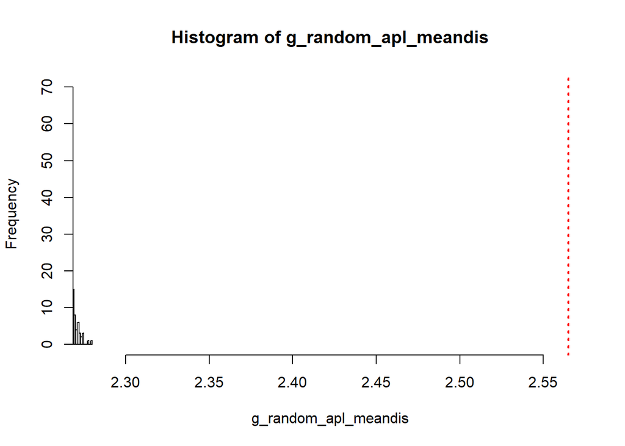

## Transitivity

Gerade in Sozialen Netzwerken wichtig. Perfekte Transitivität würde bedeuten das X und Y miteinander verbunden sind, Y und Z auch und Z und X ebenfalls. Ab solchen Dreierkonstellationen, bei denen jeder mit jedem verbunden ist, redet man von Cliquen (siehe unten). Das ist in real vorkommenden Netzwerken allerdings selten. Der Transitivitäts-Koeffizient misst die Wahrscheinlichkeit, dass die benachbarten Knoten eines Knotens ebenfalls miteinander verbunden sind. Dies wird manchmal auch als Clustering-Koeffizient bezeichnet. In unserem Fall ist die Wahrscheinlichkeit bei etwas mehr als einem Viertel (wieder durch randomisation testbar, ob das viel oder wenig ist).

Die Transitivität kann auch lokal für jeden Knoten errechnet werden. Er nimmt dann quasi alle 3er-Konstellationen wo dieser Knoten dabei ist und guckt sich die beiden anderen Knoten an.

Hinweis: Ob das Netzwerk gerichtet ist oder nicht, wird dabei außer Acht gelassen.

```
## [1] 0.2867866
```

Bei gleicher “Dichte” des Netzwerks ist es bei unserem Netzwerk deutlich wahrscheinlicher, dass auch die Nachbarn eines Knotens miteinander verbunden sind. Wieder ist das ganz gut über die Fraktionsbildung zu erklären. Bei Parteikollegen die sich gegenseitig folgen, ist es relativ wahrscheinlich, dass die beiden auch dem dritten Parteikollegen folgen.

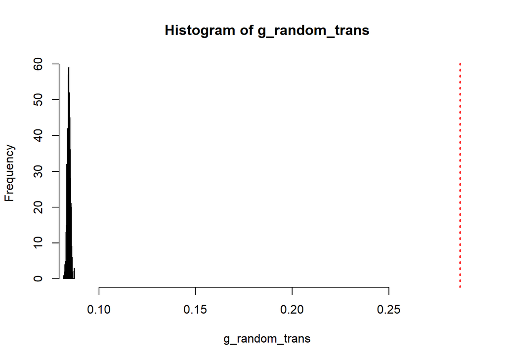

## Cliquen

Cliquen sind Zusammenschlüsse von Knoten, die alle gegenseitig miteinander verbunden sind. In unserem Netzwerk gibt es 18477 “größte” Cliquen die gleich groß sind. Diese verbinden jeweils 21 Knoten miteinander.

```
## [[1]]
## + 21/621 vertices, named, from 4bb2be0:
##  [1] 2615239693          976511129018077184  700605423
##  [4] 1112075586120400896 102948151           940691491835564032
##  [7] 3318542685          23967604            923116072856846336
## [10] 298525921           2394252247          3017471855
## [13] 2824971037          1083411992          4909186157
## [16] 306778929           83120914            2867702451
## [19] 21694393            191779603           457528606
##
## [[2]]
## + 21/621 vertices, named, from 4bb2be0:
##  [1] 2615239693          976511129018077184  700605423
##  [4] 1112075586120400896 102948151           940691491835564032
##  [7] 3318542685          23967604            923116072856846336
```

[output cut: 104 more lines]

## Assortativity

Der Assortativitätskoeffizient ist positiv, wenn ähnliche Knoten (basierend auf einer externen Eigenschaft) dazu neigen verbunden zu sein. Andernfalls ist er negativ.

In Standardfall wird die Assortativity auf Grundlage der Degrees (s.o.) berechnet. Also: Sind Knoten mit besonders vielen ein- und ausgehenden Kanten auch mit anderen high-degree-Knoten verbunden. Hier ist der Koeffizient -0.1. Man kann also nicht sagen, dass besonders zentrale Knoten anderen zentralen Knoten besonders stark folgen, aber auch nicht das Gegenteil. Das könnte dafür sprechen, dass es bspw. in jeder Fraktion Multiplikatoren gibt, die potentiell nur den high-degree-MEPs aus den anderen Fraktionen folgen und sonst eher den lower-degree-MEPs aus ihrer eigenen Fraktion.

Wenn man dem Assortativity-Index das externe Attribut der Fraktionszugehörigkeit mitgibt ist die Assortativity stark positiv, was die Fraktionsbildung im Netzwerk unterstreicht.

```
## [1] -0.1040893
```

```
## [1] 0.5543025
```

## Reciprocity

```r
reciprocity(net_igraph)
```

```
## [1] 0.4939889
```

Das Maß der Reziprozität definiert den Anteil der gegenseitigen Verbindungen in einem gerichteten Graphen. Funktioniert also nur bei gerichteten Graphen, unserer ist aber so einer, da MEP X ja bei Twitter MEP Y folgen kann, aber nicht zwangsläufig umgekehrt auch. Mit einem Wert von 0.49 werden knapp die Hälfte der Follower auch zurück gefolgt.

## Community Detection

Theoretisch könnte man den Algorithmus auch selber Gruppen erkennen lassen. Da wir aber bereits auch schon vorgegebene Gruppen (Nation und Fraktion und nationale Partei haben wir schon im Datensatz) haben, müssten wir das mal besprechen, ob das Sinn ergibt.

Könnte aber für “Bündnisse” etc. spannend sein. Oder bspw. ob sich eine Community aus überwiegend Links-Mitte und Rechts-Mitte, oder Mitte gegen Extreme oder sowas ergibt.

# Analyse der Fraktionen

```r
subnet_epp <- induced.subgraph(net_igraph, V(net_igraph)$GroupShort == "EPP")
subnet_sd <- induced.subgraph(net_igraph, V(net_igraph)$GroupShort == "S&D")
subnet_green <- induced.subgraph(net_igraph, V(net_igraph)$GroupShort == "Greens/EFA")
subnet_gue <- induced.subgraph(net_igraph, V(net_igraph)$GroupShort == "GUE/NGL")
subnet_id <- induced.subgraph(net_igraph, V(net_igraph)$GroupShort == "ID")
subnet_renew <- induced.subgraph(net_igraph, V(net_igraph)$GroupShort == "Renew")
subnet_ecr <- induced.subgraph(net_igraph, V(net_igraph)$GroupShort == "ECR")
subnet_ni <- induced.subgraph(net_igraph, V(net_igraph)$GroupShort == "NI")

analyse_subgraphs <- function(subg_name){
  subg <- get(subg_name)
  subg_trans <- transitivity(subg)
  subg_assort <- assortativity.degree(subg)
  subg_recip <- reciprocity(subg)
  subg_edgedens <- edge_density(subg)
  #subg_degree_out <- igraph::degree(subg, mode = "out")
  #subg_degree_in <- igraph::degree(subg, mode = "in")

  results_list <- list(
    groupname = unique(V(subg)$GroupShort),
    #indegree = subg_degree_in,
    #outdegree = subg_degree_out,
    edgedensity = subg_edgedens,
    transitivity = subg_trans,
    assortativity = subg_assort,
    reciprocity = subg_recip
  )
  return(results_list)
}


subgraph_results <- lapply(ls(pattern = "subnet_"), analyse_subgraphs) %>%
  rbindlist() %>%
  mutate(groupname = factor(groupname, levels= c("ID", "ECR", "EPP", "Renew", "S&D", "Greens/EFA", "GUE/NGL", "NI"))) %>%
  arrange(groupname) %>%
  mutate_if(is.numeric, round, 3)

DT::datatable(subgraph_results)
```

|  | groupname | edgedensity | transitivity | assortativity | reciprocity |
| --- | --- | --- | --- | --- | --- |
| 1 | ID | 0.145 | 0.554 | -0.2 | 0.647 |
| 2 | ECR | 0.156 | 0.755 | 0.222 | 0.689 |
| 3 | EPP | 0.133 | 0.445 | -0.203 | 0.55 |
| 4 | Renew | 0.237 | 0.537 | -0.274 | 0.56 |
| 5 | S&amp;D | 0.141 | 0.475 | -0.123 | 0.594 |
| 6 | Greens/EFA | 0.342 | 0.667 | -0.232 | 0.582 |
| 7 | GUE/NGL | 0.296 | 0.596 | -0.241 | 0.59 |
| 8 | NI | 0.333 | 0.913 | 0.481 | 0.771 |

```r
kable(subgraph_results, escape = FALSE) %>% kable_styling(c("striped", "condensed"), full_width = F)
```

| groupname | edgedensity | transitivity | assortativity | reciprocity |
| --- | --- | --- | --- | --- |
| ID | 0.145 | 0.554 | -0.200 | 0.647 |
| ECR | 0.156 | 0.755 | 0.222 | 0.689 |
| EPP | 0.133 | 0.445 | -0.203 | 0.550 |
| Renew | 0.237 | 0.537 | -0.274 | 0.560 |
| S&D | 0.141 | 0.475 | -0.123 | 0.594 |
| Greens/EFA | 0.342 | 0.667 | -0.232 | 0.582 |
| GUE/NGL | 0.296 | 0.596 | -0.241 | 0.590 |
| NI | 0.333 | 0.913 | 0.481 | 0.771 |

Hier erkennt man meiner Meinung nach bereits folgendes:

## Die NIs

Die NIs haben extrem hohe Werte. Die “Nicht-Fraktion” ist sehr dicht (viele Verbindungen), sie folgen sich sehr stark untereinander und folgen sich auch gegenseitig zurück. Das liegt vor allem daran, dass die NI dominiert wird, durch die Brexit-Partei und die Movimento 5 Stelle. Das diese zwei nationalen Parteien sich intern stark folgen, ergibt Sinn. Es gibt also zwei Gruppen bei den NI, die sich eben besonders stark folgen. Siehe auch Grafik.

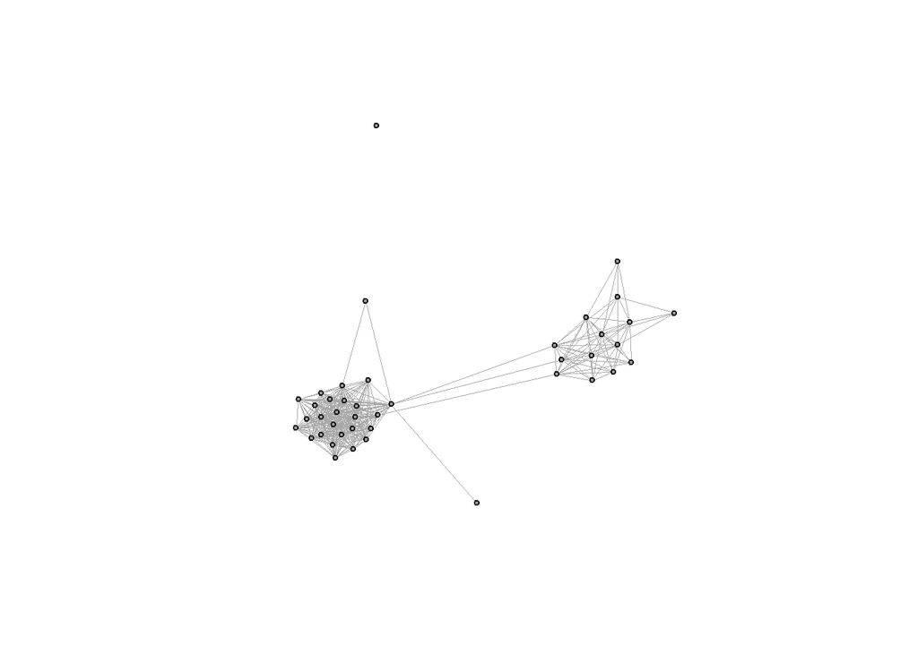

```r
set.seed(1903)
plot.igraph(subnet_ni)
```

## Fraktionen mit dem dichtesten Netzwerk

Außer der NI haben die Grünen, die GUE/NGL und Renew Europe die höchste Dichte, also den höchsten Anteil an existierenden Verbindungen an allen mööglichen. Könnte bspw. am Alter liegen (tendenziell jüngere Fraktionen), die dann eben social-media-affiner sind. Kommt drauf an, ob es sich lohnt hier hinterher zu forschen (Alter wäre prinzipiell möglich).

## Extreme Parteien anders als Mitte?

Der Transitivitäts-Koeffizient misst die Wahrscheinlichkeit, dass die benachbarten Knoten eines Knotens ebenfalls miteinander verbunden sind. Hohe Werte weisen diesmal abgesehen von den NI auch die ECR und die Grünen auf. Bei der reciprocity liegen sogar ECR und ID vorne.

Könnte man ein bisschen das Argument draus machen, dass die right-wings sehr stark drauf achten, dass sie ihren Leuten auch zurück folgen, aber auch nicht unbedingt mehr (also nicht darüber hinaus auch noch nach weiteren Kolleg*innen Ausschau halten). Die ECR versucht aber eben doch so eine “Fraktionsidentität” auch auf Twitter zu konstruieren.

S&D und EPP liegen jedenfalls häufiger maximal im Mittelfeld, sind demnach eher unterdurchschnittlich vernetzt. Auch das müsste man aber eigentlich für alle nochmal mit ERGM testen.

## Fraktionsbildung geht über Eliten

Hier findet demnach keine Elitenbildung auf Twitter statt, wo auch die Fraktionseliten nur anderen Fraktionseliten folgen, sondern im Vordergrund steht das statusunabhängige Folgen von Mitgliedern der Fraktion.

# Grafisch

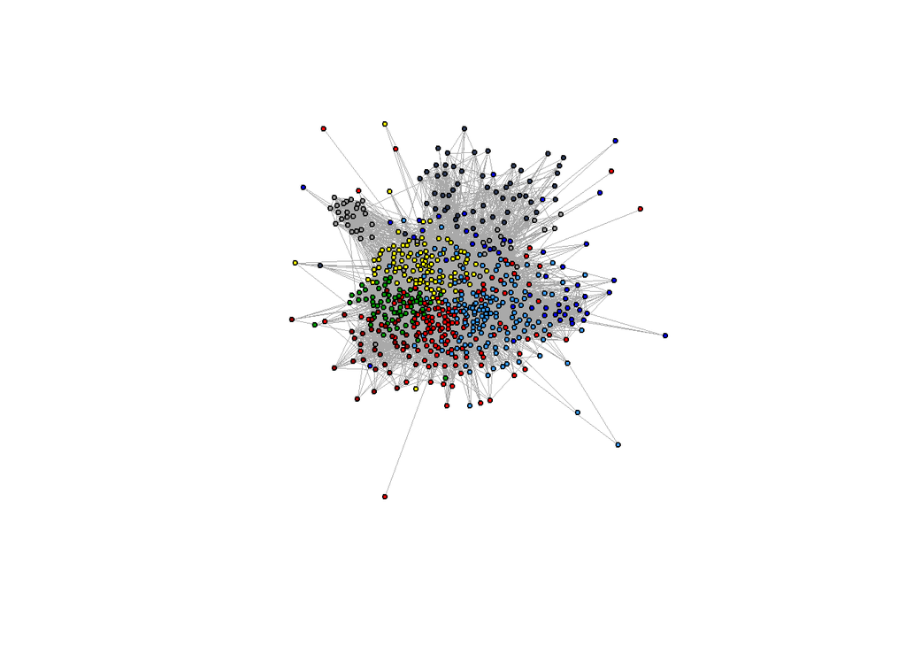

```r
set.seed(1904)
plot.igraph(net_igraph)
```

Abschließend der Netzwerk-Graph insgesamt: Man sieht sehr gut, dass Fraktionen sich zusammenfinden. Außerdem lassen sich politische Lager ebenfalls erkennen. Der ECR-Knubbel ist näher an ID und EPP als am linken Spektrum. ID fällt etwas aus der allgemeinen Punktwolke heraus. Ebenfalls gibt es links oberhalb der Renew eine Gruppe grauer Knoten. Das sind die Abgeordneten der Brexit-Party.